# DataFest 2017 Data Munging with R and dplyr

March 23rd, 2017

## Set up & Configuration

## Datasets, presentation, source code

- That data we will be using today is available via the `nycflights13` package.
  - In R, run

```r
install.packages("nycflights13")
```

- The slides and all source files for this presentation can be found at
  - https://git.io/vSe0W

## Welcome to the Hadleyverse

For today's session we will be using a number of R packages that have been developed by Hadley Wickham.

All of these packages are available on CRAN, before starting we want to make sure that everyone is using the most current available versions.

```r
install.packages(c("dplyr","readr","magrittr","lubridate"))
```

Also - now is a good time to check that your version of R is up-to-date. If you are not running version 3.2.5 or later it is time to update. After updating R be sure to also update your packages.

## readr

## readr

This is a recent package that is designed to be a fast and friendly way of reading tabular data into R.

Core features:

- Faster than base R (~4x)
- No strings as factors
- No column name mangling
- Consistent argument/function naming scheme
- Plays nice with dplyr (`tbl_df`)
- Progress bars

## Example (csv)

```r
library(readr)
library(dplyr)
```

```r
(mtcars = read_csv(system.file("extdata/mtcars.csv", package = "readr")))
```

```
## # A tibble: 32 × 11
##      mpg   cyl  disp    hp  drat    wt  qsec    vs    am  gear  carb
##    <dbl> <int> <dbl> <int> <dbl> <dbl> <dbl> <int> <int> <int> <int>
## 1   21.0     6 160.0   110  3.90 2.620 16.46     0     1     4     4
## 2   21.0     6 160.0   110  3.90 2.875 17.02     0     1     4     4
## 3   22.8     4 108.0    93  3.85 2.320 18.61     1     1     4     1
## 4   21.4     6 258.0   110  3.08 3.215 19.44     1     0     3     1
## 5   18.7     8 360.0   175  3.15 3.440 17.02     0     0     3     2
## 6   18.1     6 225.0   105  2.76 3.460 20.22     1     0     3     1
## 7   14.3     8 360.0   245  3.21 3.570 15.84     0     0     3     4
## 8   24.4     4 146.7    62  3.69 3.190 20.00     1     0     4     2
## 9   22.8     4 140.8    95  3.92 3.150 22.90     1     0     4     2
## 10  19.2     6 167.6   123  3.92 3.440 18.30     1     0     4     4
## # ... with 22 more rows
```

```r
str(mtcars)
```

```
## Classes 'tbl_df', 'tbl' and 'data.frame':    32 obs. of  11 variables:
##  $ mpg : num  21 21 22.8 21.4 18.7 18.1 14.3 24.4 22.8 19.2 ...
##  $ cyl : int  6 6 4 6 8 6 8 4 4 6 ...
##  $ disp: num  160 160 108 258 360 ...
##  $ hp  : int  110 110 93 110 175 105 245 62 95 123 ...
##  $ drat: num  3.9 3.9 3.85 3.08 3.15 2.76 3.21 3.69 3.92 3.92 ...
##  $ wt  : num  2.62 2.88 2.32 3.21 3.44 ...
##  $ qsec: num  16.5 17 18.6 19.4 17 ...
##  $ vs  : int  0 0 1 1 0 1 0 1 1 1 ...
##  $ am  : int  1 1 1 0 0 0 0 0 0 0 ...
##  $ gear: int  4 4 4 3 3 3 3 4 4 4 ...
##  $ carb: int  4 4 1 1 2 1 4 2 2 4 ...
##  - attr(*, "spec")=List of 2
##   ..$ cols   :List of 11
##   .. ..$ mpg : list()
##   .. .. ..- attr(*, "class")= chr  "collector_double" "collector"
##   .. ..$ cyl : list()
##   .. .. ..- attr(*, "class")= chr  "collector_integer" "collector"
##   .. ..$ disp: list()
##   .. .. ..- attr(*, "class")= chr  "collector_double" "collector"
##   .. ..$ hp  : list()
##   .. .. ..- attr(*, "class")= chr  "collector_integer" "collector"
##   .. ..$ drat: list()
##   .. .. ..- attr(*, "class")= chr  "collector_double" "collector"
##   .. ..$ wt  : list()
##   .. .. ..- attr(*, "class")= chr  "collector_double" "collector"
##   .. ..$ qsec: list()
##   .. .. ..- attr(*, "class")= chr  "collector_double" "collector"
##   .. ..$ vs  : list()
##   .. .. ..- attr(*, "class")= chr  "collector_integer" "collector"
##   .. ..$ am  : list()
##   .. .. ..- attr(*, "class")= chr  "collector_integer" "collector"
##   .. ..$ gear: list()
##   .. .. ..- attr(*, "class")= chr  "collector_integer" "collector"
##   .. ..$ carb: list()
##   .. .. ..- attr(*, "class")= chr  "collector_integer" "collector"
##   ..$ default: list()
##   .. ..- attr(*, "class")= chr  "collector_guess" "collector"
##   ..- attr(*, "class")= chr "col_spec"
```

```r
(mtcars = read_csv(system.file("extdata/mtcars.csv.zip", package = "readr")))
```

```
## # A tibble: 32 × 11
##      mpg   cyl  disp    hp  drat    wt  qsec    vs    am  gear  carb
##    <dbl> <int> <dbl> <int> <dbl> <dbl> <dbl> <int> <int> <int> <int>
## 1   21.0     6 160.0   110  3.90 2.620 16.46     0     1     4     4
## 2   21.0     6 160.0   110  3.90 2.875 17.02     0     1     4     4
## 3   22.8     4 108.0    93  3.85 2.320 18.61     1     1     4     1
## 4   21.4     6 258.0   110  3.08 3.215 19.44     1     0     3     1
## 5   18.7     8 360.0   175  3.15 3.440 17.02     0     0     3     2
## 6   18.1     6 225.0   105  2.76 3.460 20.22     1     0     3     1
## 7   14.3     8 360.0   245  3.21 3.570 15.84     0     0     3     4
## 8   24.4     4 146.7    62  3.69 3.190 20.00     1     0     4     2
## 9   22.8     4 140.8    95  3.92 3.150 22.90     1     0     4     2
## 10  19.2     6 167.6   123  3.92 3.440 18.30     1     0     4     4
## # ... with 22 more rows
```

## Pipes

## magrittr

[figure not shown]

[figure not shown]

This is an idea that has been around for a long time - particularly in the unix ecosystem.

- Complex tasks can be accomplished by stringing together many simple tools - syntax is important for efficiency / readability
- The idea of pipes is that the result of the previous command is passed to the next command, which allows many tools to be strung together - from left to right.
- In R, Magrittr introduces the `%>%` pipe operator which runs the expression of the left and passes the result as the *first* argument to expression on the right.

## Approaches

All of the following are fine, it amounts to preference.

Nested:

```r
h( g( f(x), y=1), z=1 )
```

Piped:

```r
f(x) %>% g(y=1) %>% h(z=1)
```

Intermediate:

```r
res = f(x)
res = g(res, y=1)
res = h(res, z=1)
```

## What about other arguments?

Sometimes we want to send our results to a function argument *other* than first one or we want to use the previous result for multiple arguments. In these cases we refer to the previous result using `.`.

```r
data.frame(a=1:3,b=3:1) %>% lm(a~b,data=.)
```

```
##
## Call:
## lm(formula = a ~ b, data = .)
##
## Coefficients:
## (Intercept)            b
##           4           -1
```

```r
data.frame(a=1:3,b=3:1) %>% .[[1]]
```

```
## [1] 1 2 3
```

```r
data.frame(a=1:3,b=3:1) %>% .[[length(.)]]
```

```
## [1] 3 2 1
```

## Aliases for common operations

Sometimes we want to pass our results to some basic operation such as multiplication, addition, etc. This can be as in the following example.

```r
data.frame(aa=1:5,bb=5:1,cc=10) %>% .[[1]] %>% `*`(5) %>% `+`(5) %>%
{
  cat("Max:", max(.), "Min:", min(.), "Avg:", mean(.),"Sd:", sd(.), "\n")
}
```

```
## Max: 30 Min: 10 Avg: 20 Sd: 7.905694
```

## dplyr

## A Grammar of Data Manipulation

dplyr is based on the concepts of functions as verbs that manipulate data frames.

Single data frame functions / verbs:

- `tbl_df()`: add the `tbl_df` class to a data frame
- `filter()`: pick rows matching given criteria
- `slice()`: pick rows by index(es)
- `select()`: pick columns by name
- `rename()`: rename column(s)
- `arrange()`: sort / reorder row(s)
- `mutate()`: add new variables / columns
- `transmute()`: create new data frame
- `distinct()`: filter for unique rows
- `sample_n()` / `sample_frac()`: randomly sample rows
- `summarise()`: reduce variables to values
- `group_by()`: indicates values to group by when summarizing

## dplyr rules

- First argument is a data frame
- Subsequent arguments say what to do with data frame
- Always return a data frame
- Don't modify in place

## Example Data

We will demonstrate dplyr's functionality using the nycflights13 data.

```r
str(flights)
```

```
## Classes 'tbl_df', 'tbl' and 'data.frame':    336776 obs. of  19 variables:
##  $ year          : int  2013 2013 2013 2013 2013 2013 2013 2013 2013 2013 ...
##  $ month         : int  1 1 1 1 1 1 1 1 1 1 ...
##  $ day           : int  1 1 1 1 1 1 1 1 1 1 ...
##  $ dep_time      : int  517 533 542 544 554 554 555 557 557 558 ...
##  $ sched_dep_time: int  515 529 540 545 600 558 600 600 600 600 ...
##  $ dep_delay     : num  2 4 2 -1 -6 -4 -5 -3 -3 -2 ...
##  $ arr_time      : int  830 850 923 1004 812 740 913 709 838 753 ...
##  $ sched_arr_time: int  819 830 850 1022 837 728 854 723 846 745 ...
##  $ arr_delay     : num  11 20 33 -18 -25 12 19 -14 -8 8 ...
##  $ carrier       : chr  "UA" "UA" "AA" "B6" ...
##  $ flight        : int  1545 1714 1141 725 461 1696 507 5708 79 301 ...
##  $ tailnum       : chr  "N14228" "N24211" "N619AA" "N804JB" ...
##  $ origin        : chr  "EWR" "LGA" "JFK" "JFK" ...
##  $ dest          : chr  "IAH" "IAH" "MIA" "BQN" ...
##  $ air_time      : num  227 227 160 183 116 150 158 53 140 138 ...
##  $ distance      : num  1400 1416 1089 1576 762 ...
##  $ hour          : num  5 5 5 5 6 5 6 6 6 6 ...
##  $ minute        : num  15 29 40 45 0 58 0 0 0 0 ...
##  $ time_hour     : POSIXct, format: "2013-01-01 05:00:00" "2013-01-01 05:00:00" "2013-01-01 05:00:00" ...
```

## tbl_df()?

```r
flights
```

```
## # A tibble: 336,776 × 19
##     year month   day dep_time sched_dep_time dep_delay arr_time sched_arr_time arr_delay carrier
##    <int> <int> <int>    <int>          <int>     <dbl>    <int>          <int>     <dbl>   <chr>
## 1   2013     1     1      517            515         2      830            819        11      UA
## 2   2013     1     1      533            529         4      850            830        20      UA
## 3   2013     1     1      542            540         2      923            850        33      AA
## 4   2013     1     1      544            545        -1     1004           1022       -18      B6
## 5   2013     1     1      554            600        -6      812            837       -25      DL
## 6   2013     1     1      554            558        -4      740            728        12      UA
## 7   2013     1     1      555            600        -5      913            854        19      B6
## 8   2013     1     1      557            600        -3      709            723       -14      EV
## 9   2013     1     1      557            600        -3      838            846        -8      B6
## 10  2013     1     1      558            600        -2      753            745         8      AA
## # ... with 336,766 more rows, and 9 more variables: flight <int>, tailnum <chr>, origin <chr>,
## #   dest <chr>, air_time <dbl>, distance <dbl>, hour <dbl>, minute <dbl>, time_hour <dttm>
```

## filter() - March flights

```r
flights %>% filter(month == 3)
```

```
## # A tibble: 28,834 × 19
##     year month   day dep_time sched_dep_time dep_delay arr_time sched_arr_time arr_delay carrier
##    <int> <int> <int>    <int>          <int>     <dbl>    <int>          <int>     <dbl>   <chr>
## 1   2013     3     1        4           2159       125      318             56       142      B6
## 2   2013     3     1       50           2358        52      526            438        48      B6
## 3   2013     3     1      117           2245       152      223           2354       149      B6
## 4   2013     3     1      454            500        -6      633            648       -15      US
## 5   2013     3     1      505            515       -10      746            810       -24      UA
## 6   2013     3     1      521            530        -9      813            827       -14      UA
## 7   2013     3     1      537            540        -3      856            850         6      AA
## 8   2013     3     1      541            545        -4     1014           1023        -9      B6
## 9   2013     3     1      549            600       -11      639            703       -24      US
## 10  2013     3     1      550            600       -10      747            801       -14      EV
## # ... with 28,824 more rows, and 9 more variables: flight <int>, tailnum <chr>, origin <chr>,
## #   dest <chr>, air_time <dbl>, distance <dbl>, hour <dbl>, minute <dbl>, time_hour <dttm>
```

## filter() - Flights in the first 7 days of March

```r
flights %>% filter(month == 3, day <= 7)
```

```
## # A tibble: 6,530 × 19
##     year month   day dep_time sched_dep_time dep_delay arr_time sched_arr_time arr_delay carrier
##    <int> <int> <int>    <int>          <int>     <dbl>    <int>          <int>     <dbl>   <chr>
## 1   2013     3     1        4           2159       125      318             56       142      B6
## 2   2013     3     1       50           2358        52      526            438        48      B6
## 3   2013     3     1      117           2245       152      223           2354       149      B6
## 4   2013     3     1      454            500        -6      633            648       -15      US
## 5   2013     3     1      505            515       -10      746            810       -24      UA
## 6   2013     3     1      521            530        -9      813            827       -14      UA
## 7   2013     3     1      537            540        -3      856            850         6      AA
## 8   2013     3     1      541            545        -4     1014           1023        -9      B6
## 9   2013     3     1      549            600       -11      639            703       -24      US
## 10  2013     3     1      550            600       -10      747            801       -14      EV
## # ... with 6,520 more rows, and 9 more variables: flight <int>, tailnum <chr>, origin <chr>,
## #   dest <chr>, air_time <dbl>, distance <dbl>, hour <dbl>, minute <dbl>, time_hour <dttm>
```

## filter() - Flights to LAX or RDU in March

```r
flights %>% filter(dest == "LAX" | dest == "RDU", month==3)
```

```
## # A tibble: 1,935 × 19
##     year month   day dep_time sched_dep_time dep_delay arr_time sched_arr_time arr_delay carrier
##    <int> <int> <int>    <int>          <int>     <dbl>    <int>          <int>     <dbl>   <chr>
## 1   2013     3     1      607            610        -3      832            925       -53      UA
## 2   2013     3     1      608            615        -7      737            750       -13      MQ
## 3   2013     3     1      623            630        -7      753            810       -17      EV
## 4   2013     3     1      629            632        -3      844            952       -68      UA
## 5   2013     3     1      657            700        -3      953           1034       -41      DL
## 6   2013     3     1      714            715        -1      939           1037       -58      B6
## 7   2013     3     1      716            710         6      958           1035       -37      VX
## 8   2013     3     1      727            730        -3     1007           1100       -53      AA
## 9   2013     3     1      803            810        -7      923            955       -32      MQ
## 10  2013     3     1      823            824        -1      954           1014       -20      EV
## # ... with 1,925 more rows, and 9 more variables: flight <int>, tailnum <chr>, origin <chr>,
## #   dest <chr>, air_time <dbl>, distance <dbl>, hour <dbl>, minute <dbl>, time_hour <dttm>
```

## slice() - First 10 flights

```r
flights %>% slice(1:10)
```

```
## # A tibble: 10 × 19
##     year month   day dep_time sched_dep_time dep_delay arr_time sched_arr_time arr_delay carrier
##    <int> <int> <int>    <int>          <int>     <dbl>    <int>          <int>     <dbl>   <chr>
## 1   2013     1     1      517            515         2      830            819        11      UA
## 2   2013     1     1      533            529         4      850            830        20      UA
## 3   2013     1     1      542            540         2      923            850        33      AA
## 4   2013     1     1      544            545        -1     1004           1022       -18      B6
## 5   2013     1     1      554            600        -6      812            837       -25      DL
## 6   2013     1     1      554            558        -4      740            728        12      UA
## 7   2013     1     1      555            600        -5      913            854        19      B6
## 8   2013     1     1      557            600        -3      709            723       -14      EV
## 9   2013     1     1      557            600        -3      838            846        -8      B6
## 10  2013     1     1      558            600        -2      753            745         8      AA
## # ... with 9 more variables: flight <int>, tailnum <chr>, origin <chr>, dest <chr>, air_time <dbl>,
## #   distance <dbl>, hour <dbl>, minute <dbl>, time_hour <dttm>
```

```r
flights %>% slice((n()-5):n())
```

```
## # A tibble: 6 × 19
##    year month   day dep_time sched_dep_time dep_delay arr_time sched_arr_time arr_delay carrier
##   <int> <int> <int>    <int>          <int>     <dbl>    <int>          <int>     <dbl>   <chr>
## 1  2013     9    30       NA           1842        NA       NA           2019        NA      EV
## 2  2013     9    30       NA           1455        NA       NA           1634        NA      9E
## 3  2013     9    30       NA           2200        NA       NA           2312        NA      9E
## 4  2013     9    30       NA           1210        NA       NA           1330        NA      MQ
## 5  2013     9    30       NA           1159        NA       NA           1344        NA      MQ
## 6  2013     9    30       NA            840        NA       NA           1020        NA      MQ
## # ... with 9 more variables: flight <int>, tailnum <chr>, origin <chr>, dest <chr>, air_time <dbl>,
## #   distance <dbl>, hour <dbl>, minute <dbl>, time_hour <dttm>
```

## select() - Individual Columns

```r
flights %>% select(year, month, day)
```

```
## # A tibble: 336,776 × 3
##     year month   day
##    <int> <int> <int>
## 1   2013     1     1
## 2   2013     1     1
## 3   2013     1     1
## 4   2013     1     1
## 5   2013     1     1
## 6   2013     1     1
## 7   2013     1     1
## 8   2013     1     1
## 9   2013     1     1
## 10  2013     1     1
## # ... with 336,766 more rows
```

## select() - Exclude Columns

```r
flights %>% select(-year, -month, -day)
```

```
## # A tibble: 336,776 × 16
##    dep_time sched_dep_time dep_delay arr_time sched_arr_time arr_delay carrier flight tailnum
##       <int>          <int>     <dbl>    <int>          <int>     <dbl>   <chr>  <int>   <chr>
## 1       517            515         2      830            819        11      UA   1545  N14228
## 2       533            529         4      850            830        20      UA   1714  N24211
## 3       542            540         2      923            850        33      AA   1141  N619AA
## 4       544            545        -1     1004           1022       -18      B6    725  N804JB
## 5       554            600        -6      812            837       -25      DL    461  N668DN
## 6       554            558        -4      740            728        12      UA   1696  N39463
## 7       555            600        -5      913            854        19      B6    507  N516JB
## 8       557            600        -3      709            723       -14      EV   5708  N829AS
## 9       557            600        -3      838            846        -8      B6     79  N593JB
## 10      558            600        -2      753            745         8      AA    301  N3ALAA
## # ... with 336,766 more rows, and 7 more variables: origin <chr>, dest <chr>, air_time <dbl>,
## #   distance <dbl>, hour <dbl>, minute <dbl>, time_hour <dttm>
```

## select() - Ranges

```r
flights %>% select(year:day)
```

```
## # A tibble: 336,776 × 3
##     year month   day
##    <int> <int> <int>
## 1   2013     1     1
## 2   2013     1     1
## 3   2013     1     1
## 4   2013     1     1
## 5   2013     1     1
## 6   2013     1     1
## 7   2013     1     1
## 8   2013     1     1
## 9   2013     1     1
## 10  2013     1     1
## # ... with 336,766 more rows
```

## select() - Exclusion Ranges

```r
flights %>% select(-(year:day))
```

```
## # A tibble: 336,776 × 16
##    dep_time sched_dep_time dep_delay arr_time sched_arr_time arr_delay carrier flight tailnum
##       <int>          <int>     <dbl>    <int>          <int>     <dbl>   <chr>  <int>   <chr>
## 1       517            515         2      830            819        11      UA   1545  N14228
## 2       533            529         4      850            830        20      UA   1714  N24211
## 3       542            540         2      923            850        33      AA   1141  N619AA
## 4       544            545        -1     1004           1022       -18      B6    725  N804JB
## 5       554            600        -6      812            837       -25      DL    461  N668DN
## 6       554            558        -4      740            728        12      UA   1696  N39463
## 7       555            600        -5      913            854        19      B6    507  N516JB
## 8       557            600        -3      709            723       -14      EV   5708  N829AS
## 9       557            600        -3      838            846        -8      B6     79  N593JB
## 10      558            600        -2      753            745         8      AA    301  N3ALAA
## # ... with 336,766 more rows, and 7 more variables: origin <chr>, dest <chr>, air_time <dbl>,
## #   distance <dbl>, hour <dbl>, minute <dbl>, time_hour <dttm>
```

## select() - Matching

```r
flights %>% select(contains("dep"),
                   contains("arr"))
```

```
## # A tibble: 336,776 × 7
##    dep_time sched_dep_time dep_delay arr_time sched_arr_time arr_delay carrier
##       <int>          <int>     <dbl>    <int>          <int>     <dbl>   <chr>
## 1       517            515         2      830            819        11      UA
## 2       533            529         4      850            830        20      UA
## 3       542            540         2      923            850        33      AA
## 4       544            545        -1     1004           1022       -18      B6
## 5       554            600        -6      812            837       -25      DL
## 6       554            558        -4      740            728        12      UA
## 7       555            600        -5      913            854        19      B6
## 8       557            600        -3      709            723       -14      EV
## 9       557            600        -3      838            846        -8      B6
## 10      558            600        -2      753            745         8      AA
## # ... with 336,766 more rows
```

```r
flights %>% select(contains("dep"),
                   starts_with("arr"))
```

```
## # A tibble: 336,776 × 5
##    dep_time sched_dep_time dep_delay arr_time arr_delay
##       <int>          <int>     <dbl>    <int>     <dbl>
## 1       517            515         2      830        11
## 2       533            529         4      850        20
## 3       542            540         2      923        33
## 4       544            545        -1     1004       -18
## 5       554            600        -6      812       -25
## 6       554            558        -4      740        12
## 7       555            600        -5      913        19
## 8       557            600        -3      709       -14
## 9       557            600        -3      838        -8
## 10      558            600        -2      753         8
## # ... with 336,766 more rows
```

## rename()

```r
flights %>% rename(tail_number = tailnum)
```

```
## # A tibble: 336,776 × 19
##     year month   day dep_time sched_dep_time dep_delay arr_time sched_arr_time arr_delay carrier
##    <int> <int> <int>    <int>          <int>     <dbl>    <int>          <int>     <dbl>   <chr>
## 1   2013     1     1      517            515         2      830            819        11      UA
## 2   2013     1     1      533            529         4      850            830        20      UA
## 3   2013     1     1      542            540         2      923            850        33      AA
## 4   2013     1     1      544            545        -1     1004           1022       -18      B6
## 5   2013     1     1      554            600        -6      812            837       -25      DL
## 6   2013     1     1      554            558        -4      740            728        12      UA
## 7   2013     1     1      555            600        -5      913            854        19      B6
## 8   2013     1     1      557            600        -3      709            723       -14      EV
## 9   2013     1     1      557            600        -3      838            846        -8      B6
## 10  2013     1     1      558            600        -2      753            745         8      AA
## # ... with 336,766 more rows, and 9 more variables: flight <int>, tail_number <chr>, origin <chr>,
## #   dest <chr>, air_time <dbl>, distance <dbl>, hour <dbl>, minute <dbl>, time_hour <dttm>
```

## arrange()

```r
flights %>% filter(month==3,day==2) %>% arrange(origin, dest)
```

```
## # A tibble: 765 × 19
##     year month   day dep_time sched_dep_time dep_delay arr_time sched_arr_time arr_delay carrier
##    <int> <int> <int>    <int>          <int>     <dbl>    <int>          <int>     <dbl>   <chr>
## 1   2013     3     2     1336           1329         7     1426           1432        -6      EV
## 2   2013     3     2      628            629        -1      837            849       -12      DL
## 3   2013     3     2      637            640        -3      903            915       -12      EV
## 4   2013     3     2      743            745        -2      945           1010       -25      DL
## 5   2013     3     2      857            900        -3     1117           1126        -9      DL
## 6   2013     3     2     1027           1030        -3     1234           1247       -13      DL
## 7   2013     3     2     1134           1145       -11     1332           1359       -27      DL
## 8   2013     3     2     1412           1415        -3     1636           1630         6      DL
## 9   2013     3     2     1633           1636        -3     1848           1908       -20      EV
## 10  2013     3     2     1655           1700        -5     1857           1924       -27      DL
## # ... with 755 more rows, and 9 more variables: flight <int>, tailnum <chr>, origin <chr>,
## #   dest <chr>, air_time <dbl>, distance <dbl>, hour <dbl>, minute <dbl>, time_hour <dttm>
```

## arrange() & desc()

```r
flights %>% filter(month==3,day==2) %>% arrange(desc(origin), dest)
```

```
## # A tibble: 765 × 19
##     year month   day dep_time sched_dep_time dep_delay arr_time sched_arr_time arr_delay carrier
##    <int> <int> <int>    <int>          <int>     <dbl>    <int>          <int>     <dbl>   <chr>
## 1   2013     3     2      555            600        -5      822            815         7      FL
## 2   2013     3     2      556            600        -4      822            829        -7      DL
## 3   2013     3     2      758            800        -2     1009           1031       -22      DL
## 4   2013     3     2      808            810        -2     1022           1043       -21      FL
## 5   2013     3     2      828            835        -7     1050           1105       -15      MQ
## 6   2013     3     2      857            900        -3     1126           1142       -16      DL
## 7   2013     3     2      957           1000        -3     1224           1234       -10      DL
## 8   2013     3     2     1158           1200        -2     1411           1430       -19      MQ
## 9   2013     3     2     1159           1200        -1     1429           1438        -9      DL
## 10  2013     3     2     1259           1300        -1     1510           1535       -25      DL
## # ... with 755 more rows, and 9 more variables: flight <int>, tailnum <chr>, origin <chr>,
## #   dest <chr>, air_time <dbl>, distance <dbl>, hour <dbl>, minute <dbl>, time_hour <dttm>
```

## mutate()

```r
flights %>% select(1:3) %>% mutate(date = paste(month,day,year,sep="/") %>% mdy())
```

```
## # A tibble: 336,776 × 4
##     year month   day       date
##    <int> <int> <int>     <date>
## 1   2013     1     1 2013-01-01
## 2   2013     1     1 2013-01-01
## 3   2013     1     1 2013-01-01
## 4   2013     1     1 2013-01-01
## 5   2013     1     1 2013-01-01
## 6   2013     1     1 2013-01-01
## 7   2013     1     1 2013-01-01
## 8   2013     1     1 2013-01-01
## 9   2013     1     1 2013-01-01
## 10  2013     1     1 2013-01-01
## # ... with 336,766 more rows
```

## transmute()

```r
flights %>% select(1:3) %>% transmute(date = paste(month,day,year,sep="/") %>% mdy())
```

```
## # A tibble: 336,776 × 1
##          date
##        <date>
## 1  2013-01-01
## 2  2013-01-01
## 3  2013-01-01
## 4  2013-01-01
## 5  2013-01-01
## 6  2013-01-01
## 7  2013-01-01
## 8  2013-01-01
## 9  2013-01-01
## 10 2013-01-01
## # ... with 336,766 more rows
```

## distinct()

```r
flights %>% select(origin, dest) %>% distinct() %>% arrange(origin,dest)
```

```
## # A tibble: 224 × 2
##    origin  dest
##     <chr> <chr>
## 1     EWR   ALB
## 2     EWR   ANC
## 3     EWR   ATL
## 4     EWR   AUS
## 5     EWR   AVL
## 6     EWR   BDL
## 7     EWR   BNA
## 8     EWR   BOS
## 9     EWR   BQN
## 10    EWR   BTV
## # ... with 214 more rows
```

## sample_n()

```r
flights %>% sample_n(10)
```

```
## # A tibble: 10 × 19
##     year month   day dep_time sched_dep_time dep_delay arr_time sched_arr_time arr_delay carrier
##    <int> <int> <int>    <int>          <int>     <dbl>    <int>          <int>     <dbl>   <chr>
## 1   2013    10     6     1638           1608        30     1751           1752        -1      B6
## 2   2013    10    25     1738           1715        23     2035           2005        30      WN
## 3   2013     9    28      905            910        -5     1118           1215       -57      AA
## 4   2013     8    13     1115           1115         0     1239           1230         9      MQ
## 5   2013     3     7      629            630        -1      743            800       -17      EV
## 6   2013    11    11      823            825        -2     1108           1144       -36      UA
## 7   2013    10    11      707            710        -3     1006           1022       -16      DL
## 8   2013     8    16     1025           1030        -5     1140           1142        -2      EV
## 9   2013     8    18     2041           2045        -4     2343           2354       -11      UA
## 10  2013    11     8      832            830         2      940            944        -4      UA
## # ... with 9 more variables: flight <int>, tailnum <chr>, origin <chr>, dest <chr>, air_time <dbl>,
## #   distance <dbl>, hour <dbl>, minute <dbl>, time_hour <dttm>
```

## sample_frac()

```r
flights %>% sample_frac(0.001)
```

```
## # A tibble: 337 × 19
##     year month   day dep_time sched_dep_time dep_delay arr_time sched_arr_time arr_delay carrier
##    <int> <int> <int>    <int>          <int>     <dbl>    <int>          <int>     <dbl>   <chr>
## 1   2013     3    31     1929           1930        -1     2242           2249        -7      B6
## 2   2013     6    16      651            659        -8      755            810       -15      EV
## 3   2013    10    14     1451           1444         7     1604           1624       -20      9E
## 4   2013     5    31      807            815        -8      948           1008       -20      US
## 5   2013     7    19      728            729        -1     1002           1019       -17      B6
## 6   2013     8    25     1243           1245        -2     1525           1550       -25      AA
## 7   2013     6     7     1936           1920        16     2114           2047        27      EV
## 8   2013     1    29     1652           1659        -7     1947           2015       -28      UA
## 9   2013     4     2      758            800        -2     1005            959         6      B6
## 10  2013     3    13     1855           1855         0     2156           2221       -25      DL
## # ... with 327 more rows, and 9 more variables: flight <int>, tailnum <chr>, origin <chr>,
## #   dest <chr>, air_time <dbl>, distance <dbl>, hour <dbl>, minute <dbl>, time_hour <dttm>
```

## summarise()

```r
flights %>% mutate(date = paste(month,day,year,sep="/") %>% mdy()) %>%
            summarize(n(), min(date), max(date))
```

```
## # A tibble: 1 × 3
##    `n()` `min(date)` `max(date)`
##    <int>      <date>      <date>
## 1 336776  2013-01-01  2013-12-31
```

## group_by()

```r
flights %>% group_by(origin)
```

```
## Source: local data frame [336,776 x 19]
## Groups: origin [3]
##
##     year month   day dep_time sched_dep_time dep_delay arr_time sched_arr_time arr_delay carrier
##    <int> <int> <int>    <int>          <int>     <dbl>    <int>          <int>     <dbl>   <chr>
## 1   2013     1     1      517            515         2      830            819        11      UA
## 2   2013     1     1      533            529         4      850            830        20      UA
## 3   2013     1     1      542            540         2      923            850        33      AA
## 4   2013     1     1      544            545        -1     1004           1022       -18      B6
## 5   2013     1     1      554            600        -6      812            837       -25      DL
## 6   2013     1     1      554            558        -4      740            728        12      UA
## 7   2013     1     1      555            600        -5      913            854        19      B6
## 8   2013     1     1      557            600        -3      709            723       -14      EV
## 9   2013     1     1      557            600        -3      838            846        -8      B6
## 10  2013     1     1      558            600        -2      753            745         8      AA
## # ... with 336,766 more rows, and 9 more variables: flight <int>, tailnum <chr>, origin <chr>,
## #   dest <chr>, air_time <dbl>, distance <dbl>, hour <dbl>, minute <dbl>, time_hour <dttm>
```

## summarise() with group_by()

```r
flights %>% group_by(origin) %>%
            mutate(date = paste(month,day,year,sep="/") %>% mdy()) %>%
            summarize(n(), min(date), max(date))
```

```
## # A tibble: 3 × 4
##   origin  `n()` `min(date)` `max(date)`
##    <chr>  <int>      <date>      <date>
## 1    EWR 120835  2013-01-01  2013-12-31
## 2    JFK 111279  2013-01-01  2013-12-31
## 3    LGA 104662  2013-01-01  2013-12-31
```

## Example 1

Which destinations have the highest average arrival delays?

```r
by_dest <- group_by(flights,dest)
avg_arr_delay_by_dest <- summarise(by_dest,avg_arr_delay=mean(arr_delay,na.rm=TRUE))
arrange(avg_arr_delay_by_dest,desc(avg_arr_delay))
```

```
## # A tibble: 105 × 2
##     dest avg_arr_delay
##    <chr>         <dbl>
## 1    CAE      41.76415
## 2    TUL      33.65986
## 3    OKC      30.61905
## 4    JAC      28.09524
## 5    TYS      24.06920
## 6    MSN      20.19604
## 7    RIC      20.11125
## 8    CAK      19.69834
## 9    DSM      19.00574
## 10   GRR      18.18956
## # ... with 95 more rows
```

## Example 1

Equivalently, using pipes

```r
flights %>%
  group_by(dest) %>%
  summarise(avg_arr_delay=mean(arr_delay,na.rm=TRUE)) %>%
  arrange(desc(avg_arr_delay))
```

```
## # A tibble: 105 × 2
##     dest avg_arr_delay
##    <chr>         <dbl>
## 1    CAE      41.76415
## 2    TUL      33.65986
## 3    OKC      30.61905
## 4    JAC      28.09524
## 5    TYS      24.06920
## 6    MSN      20.19604
## 7    RIC      20.11125
## 8    CAK      19.69834
## 9    DSM      19.00574
## 10   GRR      18.18956
## # ... with 95 more rows
```

## Example 2

Which plane (check the tail number) flew out of each New York airport the most?

```r
flights %>%
  filter((origin=="EWR" | origin=="JFK" | origin=="LGA") & !is.na(tailnum)) %>%
  group_by(origin,tailnum) %>%
  summarise(freq=n()) %>%
  group_by(origin) %>%
  arrange(desc(freq)) %>%
  slice(1)
```

```
## Source: local data frame [3 x 3]
## Groups: origin [3]
##
##   origin tailnum  freq
##    <chr>   <chr> <int>
## 1    EWR  N15980   314
## 2    JFK  N328AA   393
## 3    LGA  N725MQ   567
```

## Example 3

Find the five longest arrival delays for each carrier.

```r
flights %>%
  group_by(carrier) %>%
  arrange(desc(arr_delay)) %>%
  slice(1:5)
```

```
## Source: local data frame [80 x 19]
## Groups: carrier [16]
##
##     year month   day dep_time sched_dep_time dep_delay arr_time sched_arr_time arr_delay carrier
##    <int> <int> <int>    <int>          <int>     <dbl>    <int>          <int>     <dbl>   <chr>
## 1   2013     2    16      757           1930       747     1013           2149       744      9E
## 2   2013     7    24     1525            815       430     1808           1030       458      9E
## 3   2013     7    10     2054           1459       355      102           1801       421      9E
## 4   2013    11    27     1503            815       408     1628            952       396      9E
## 5   2013    12    14     1425            825       360     1604            938       386      9E
## 6   2013     9    20     1139           1845      1014     1457           2210      1007      AA
## 7   2013    12     5      756           1700       896     1058           2020       878      AA
## 8   2013     5    19      713           1700       853     1007           1955       852      AA
## 9   2013    12    17      705           1700       845     1026           2020       846      AA
## 10  2013     6    27      753           1830       803      937           2015       802      AA
## # ... with 70 more rows, and 9 more variables: flight <int>, tailnum <chr>, origin <chr>,
## #   dest <chr>, air_time <dbl>, distance <dbl>, hour <dbl>, minute <dbl>, time_hour <dttm>
```

## Example 4

Find the 3 longest departure delays for each route (identified by the origin and destination pair) in the summer months (June – August)

```r
flights %>%
  filter(month >= 6 & month <= 8) %>%
  group_by(origin,dest) %>%
  arrange(desc(dep_delay)) %>%
  slice(1:3)
```

```
## Source: local data frame [591 x 19]
## Groups: origin, dest [201]
##
##     year month   day dep_time sched_dep_time dep_delay arr_time sched_arr_time arr_delay carrier
##    <int> <int> <int>    <int>          <int>     <dbl>    <int>          <int>     <dbl>   <chr>
## 1   2013     7    13     1011            730       161     1118            835       163      EV
## 2   2013     6     5     1347           1107       160     1437           1212       145      EV
## 3   2013     6     8      938            751       107     1027            856        91      EV
## 4   2013     8    17     1740           1625        75     2042           2003        39      UA
## 5   2013     7     6     1629           1615        14     1954           1953         1      UA
## 6   2013     8    24     1633           1625         8     1959           2003        -4      UA
## 7   2013     6    28      121           1659       502      329           1919       490      DL
## 8   2013     6    28      154           1820       454      405           2051       434      DL
## 9   2013     7    27     2011           1300       431     2253           1519       454      EV
## 10  2013     7    10     2056           1505       351     2347           1758       349      UA
## # ... with 581 more rows, and 9 more variables: flight <int>, tailnum <chr>, origin <chr>,
## #   dest <chr>, air_time <dbl>, distance <dbl>, hour <dbl>, minute <dbl>, time_hour <dttm>
```

## Exercises - Part 1

1. What was the shortest flight out of each airport in terms of distance? In terms of duration?
2. Which date should you fly on if you want to have the lowest possible average depature delay? What about arrival delay?
3. How many flights to Los Angeles (LAX) did each of the legacy carriers (AA, UA, DL or US) have in May from JFK, and what was their average duration?

## Merging Data

## A Grammar of Data Manipulation (cont.)

Two table functions / verbs, all functions have the form `f(a,b)`:

- `left_join` - Join matching rows from `b` to `a`, preserving all rows of `a`
- `right_join` - Join matching rows from `a` to `b`, preserving all rows of `b`.
- `inner_join` - Join data, preserving only rows with keys in both `a` and `b`.
- `full_join` - Join data, preserving all rows in both `a` and `b`.
- `semi_join` - Subset rows in `a` that have a match in `b`.
- `anti_join` - Subset rows in `a` that do not have a match in `b`.

## Joining Data

```r
addr = tibble(name = c("Alice","Bob",
                           "Carol","dave",
                           "Eve"),
                  email= c("alice@company.com",
                           "bob@company.com",
                           "carol@company.com",
                           "dave@company.com",
                           "eve@company.com"))
```

```r
phone = tibble(name = c("Bob","Carol",
                            "Eve","Eve",
                            "Frank"),
                   phone= c("919 555-1111",
                            "919 555-2222",
                            "919 555-3333",
                            "310 555-3333",
                            "919 555-4444"))
```

```r
addr
```

```
## # A tibble: 5 × 2
##    name             email
##   <chr>             <chr>
## 1 Alice alice@company.com
## 2   Bob   bob@company.com
## 3 Carol carol@company.com
## 4  dave  dave@company.com
## 5   Eve   eve@company.com
```

```r
phone
```

```
## # A tibble: 5 × 2
##    name        phone
##   <chr>        <chr>
## 1   Bob 919 555-1111
## 2 Carol 919 555-2222
## 3   Eve 919 555-3333
## 4   Eve 310 555-3333
## 5 Frank 919 555-4444
```

## Outer Join

dplyr:

```r
full_join(addr, phone)
```

```
## # A tibble: 7 × 3
##    name             email        phone
##   <chr>             <chr>        <chr>
## 1 Alice alice@company.com         <NA>
## 2   Bob   bob@company.com 919 555-1111
## 3 Carol carol@company.com 919 555-2222
## 4  dave  dave@company.com         <NA>
## 5   Eve   eve@company.com 919 555-3333
## 6   Eve   eve@company.com 310 555-3333
## 7 Frank              <NA> 919 555-4444
```

Base R:

```r
merge(addr, phone, all=TRUE)
```

```
##    name             email        phone
## 1 Alice alice@company.com         <NA>
## 2   Bob   bob@company.com 919 555-1111
## 3 Carol carol@company.com 919 555-2222
## 4  dave  dave@company.com         <NA>
## 5   Eve   eve@company.com 919 555-3333
## 6   Eve   eve@company.com 310 555-3333
## 7 Frank              <NA> 919 555-4444
```

## Inner Join

dplyr:

```r
inner_join(addr,phone)
```

```
## # A tibble: 4 × 3
##    name             email        phone
##   <chr>             <chr>        <chr>
## 1   Bob   bob@company.com 919 555-1111
## 2 Carol carol@company.com 919 555-2222
## 3   Eve   eve@company.com 919 555-3333
## 4   Eve   eve@company.com 310 555-3333
```

Base R:

```r
merge(addr, phone, all=FALSE)
```

```
##    name             email        phone
## 1   Bob   bob@company.com 919 555-1111
## 2 Carol carol@company.com 919 555-2222
## 3   Eve   eve@company.com 919 555-3333
## 4   Eve   eve@company.com 310 555-3333
```

## Left Join

dplyr:

```r
left_join(addr,phone)
```

```
## # A tibble: 6 × 3
##    name             email        phone
##   <chr>             <chr>        <chr>
## 1 Alice alice@company.com         <NA>
## 2   Bob   bob@company.com 919 555-1111
## 3 Carol carol@company.com 919 555-2222
## 4  dave  dave@company.com         <NA>
## 5   Eve   eve@company.com 919 555-3333
## 6   Eve   eve@company.com 310 555-3333
```

Base R:

```r
merge(addr, phone, all.x=TRUE)
```

```
##    name             email        phone
## 1 Alice alice@company.com         <NA>
## 2   Bob   bob@company.com 919 555-1111
## 3 Carol carol@company.com 919 555-2222
## 4  dave  dave@company.com         <NA>
## 5   Eve   eve@company.com 919 555-3333
## 6   Eve   eve@company.com 310 555-3333
```

## Right Join

dplyr:

```r
right_join(addr, phone)
```

```
## # A tibble: 5 × 3
##    name             email        phone
##   <chr>             <chr>        <chr>
## 1   Bob   bob@company.com 919 555-1111
## 2 Carol carol@company.com 919 555-2222
## 3   Eve   eve@company.com 919 555-3333
## 4   Eve   eve@company.com 310 555-3333
## 5 Frank              <NA> 919 555-4444
```

Base R:

```r
merge(addr, phone, all.y=TRUE)
```

```
##    name             email        phone
## 1   Bob   bob@company.com 919 555-1111
## 2 Carol carol@company.com 919 555-2222
## 3   Eve   eve@company.com 919 555-3333
## 4   Eve   eve@company.com 310 555-3333
## 5 Frank              <NA> 919 555-4444
```

## Semi and Anti Joins

```r
semi_join(addr, phone)
```

```
## # A tibble: 3 × 2
##    name             email
##   <chr>             <chr>
## 1   Bob   bob@company.com
## 2 Carol carol@company.com
## 3   Eve   eve@company.com
```

```r
anti_join(addr, phone)
```

```
## # A tibble: 2 × 2
##    name             email
##   <chr>             <chr>
## 1  dave  dave@company.com
## 2 Alice alice@company.com
```

## Special case - many-to-many relationships

```r
addr = tibble(name = c("Alice","Alice", "Bob","Bob"),
              email= c("alice@company.com","alice@gmail.com","bob@company.com","bob@hotmail.com"))
```

```r
phone = tibble(name = c("Alice","Alice", "Bob","Bob"),
               phone= c("919 555-1111", "310 555-2222", "919 555-3333", "310 555-3333"))
```

dplyr:

```r
full_join(addr, phone)
```

```
## # A tibble: 8 × 3
##    name             email        phone
##   <chr>             <chr>        <chr>
## 1 Alice alice@company.com 919 555-1111
## 2 Alice alice@company.com 310 555-2222
## 3 Alice   alice@gmail.com 919 555-1111
## 4 Alice   alice@gmail.com 310 555-2222
## 5   Bob   bob@company.com 919 555-3333
## 6   Bob   bob@company.com 310 555-3333
## 7   Bob   bob@hotmail.com 919 555-3333
## 8   Bob   bob@hotmail.com 310 555-3333
```

Base R:

```r
merge(addr, phone)
```

```
##    name             email        phone
## 1 Alice alice@company.com 919 555-1111
## 2 Alice alice@company.com 310 555-2222
## 3 Alice   alice@gmail.com 919 555-1111
## 4 Alice   alice@gmail.com 310 555-2222
## 5   Bob   bob@company.com 919 555-3333
## 6   Bob   bob@company.com 310 555-3333
## 7   Bob   bob@hotmail.com 919 555-3333
## 8   Bob   bob@hotmail.com 310 555-3333
```

## Example - Enhancing NYC Flights

The `nycflights13` package also contains additional information about

- `weather` - hourly meterological data for each airport
- `planes` - construction information about each plane
- `airports` - airport names and locations
- `airlines` - translation between two letter carrier codes and names

## Weather and flight delays

Lets take a quick look at the weather data, with an eye towards examining how it might affect things like flight departure delays,

```r
weather
```

```
## # A tibble: 26,130 × 15
##    origin  year month   day  hour  temp  dewp humid wind_dir wind_speed wind_gust precip pressure
##     <chr> <dbl> <dbl> <int> <int> <dbl> <dbl> <dbl>    <dbl>      <dbl>     <dbl>  <dbl>    <dbl>
## 1     EWR  2013     1     1     0 37.04 21.92 53.97      230   10.35702 11.918651      0   1013.9
## 2     EWR  2013     1     1     1 37.04 21.92 53.97      230   13.80936 15.891535      0   1013.0
## 3     EWR  2013     1     1     2 37.94 21.92 52.09      230   12.65858 14.567241      0   1012.6
## 4     EWR  2013     1     1     3 37.94 23.00 54.51      230   13.80936 15.891535      0   1012.7
## 5     EWR  2013     1     1     4 37.94 24.08 57.04      240   14.96014 17.215830      0   1012.8
## 6     EWR  2013     1     1     6 39.02 26.06 59.37      270   10.35702 11.918651      0   1012.0
## 7     EWR  2013     1     1     7 39.02 26.96 61.63      250    8.05546  9.270062      0   1012.3
## 8     EWR  2013     1     1     8 39.02 28.04 64.43      240   11.50780 13.242946      0   1012.5
## 9     EWR  2013     1     1     9 39.92 28.04 62.21      250   12.65858 14.567241      0   1012.2
## 10    EWR  2013     1     1    10 39.02 28.04 64.43      260   12.65858 14.567241      0   1011.9
## # ... with 26,120 more rows, and 2 more variables: visib <dbl>, time_hour <dttm>
```

## Join by?

Weather column definitions:

- `origin` - Weather station. Named origin to faciliate merging with flights data
- `year`, `month`, `day`, `hour` - Time of recording
- `temp`, `dewp` - Temperature and dewpoint in F
- `humid` - Relative humidity
- `wind_dir`, `wind_speed`, `wind_gust` - Wind direction (in degrees), speed and gust speed (in mph)
- `precip` - Preciptation, in inches
- `pressure` - Sea level pressure in millibars
- `visib` - Visibility in miles

```r
intersect(names(weather), names(flights))
```

```
## [1] "origin"    "year"      "month"     "day"       "hour"      "time_hour"
```

## Joining flights and weather

When joining these two data frames I will use an inner join (because I only want the flights that have the weather data, and I only want weather data when there was a flight)

```r
(flightsw = inner_join(flights, weather))
```

```
## # A tibble: 139,029 × 28
##     year month   day dep_time sched_dep_time dep_delay arr_time sched_arr_time arr_delay carrier
##    <dbl> <dbl> <int>    <int>          <int>     <dbl>    <int>          <int>     <dbl>   <chr>
## 1   2013     1     1      554            600        -6      812            837       -25      DL
## 2   2013     1     1      555            600        -5      913            854        19      B6
## 3   2013     1     1      557            600        -3      709            723       -14      EV
## 4   2013     1     1      557            600        -3      838            846        -8      B6
## 5   2013     1     1      558            600        -2      753            745         8      AA
## 6   2013     1     1      558            600        -2      849            851        -2      B6
## 7   2013     1     1      558            600        -2      853            856        -3      B6
## 8   2013     1     1      558            600        -2      924            917         7      UA
## 9   2013     1     1      558            600        -2      923            937       -14      UA
## 10  2013     1     1      559            600        -1      941            910        31      AA
## # ... with 139,019 more rows, and 18 more variables: flight <int>, tailnum <chr>, origin <chr>,
## #   dest <chr>, air_time <dbl>, distance <dbl>, hour <dbl>, minute <dbl>, time_hour <dttm>,
## #   temp <dbl>, dewp <dbl>, humid <dbl>, wind_dir <dbl>, wind_speed <dbl>, wind_gust <dbl>,
## #   precip <dbl>, pressure <dbl>, visib <dbl>
```

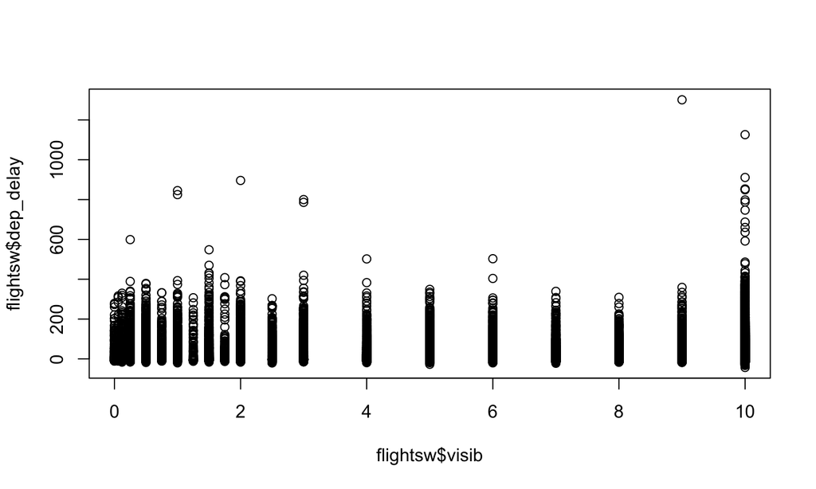

```r
plot(flightsw$visib, flightsw$dep_delay)
```

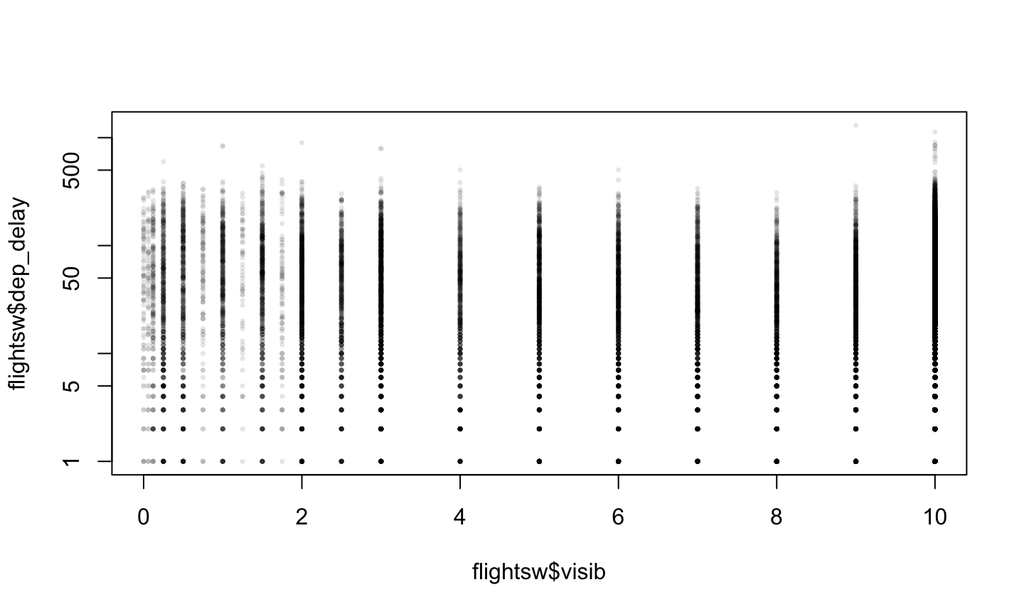

```r
plot(flightsw$visib, flightsw$dep_delay, log="y",
     pch=16, cex=0.5, col=adjustcolor("black",0.1))
```

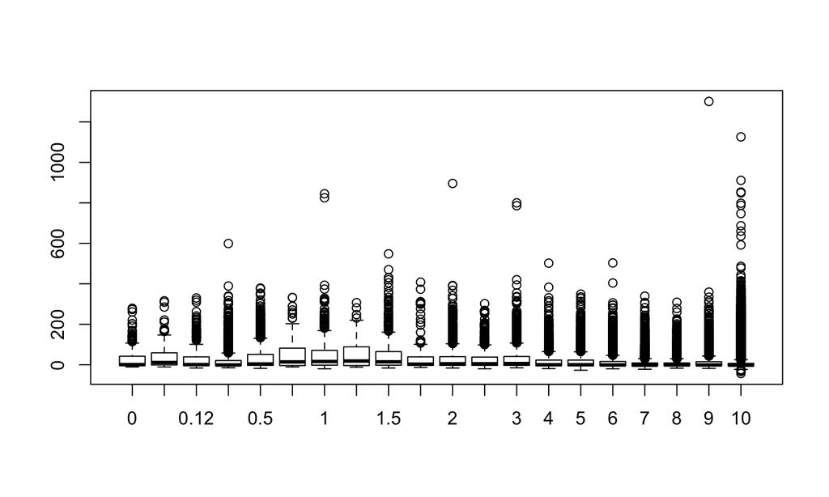

```r
boxplot(dep_delay~visib,data=flightsw)
```

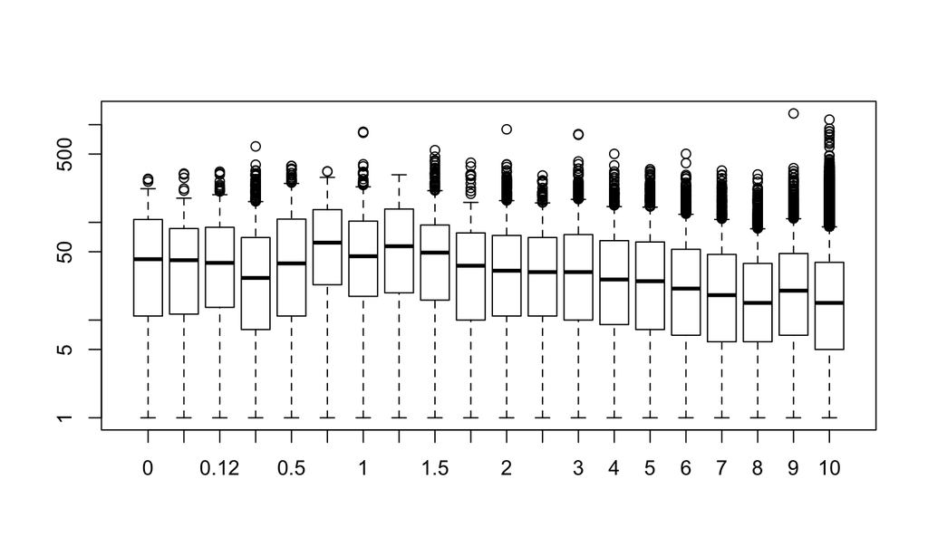

```r
filter(flightsw, dep_delay > 0)  %>%
  boxplot(dep_delay~visib,data=.,log="y")
```

```r
table(flightsw$visib)
```

```
##
##      0   0.06   0.12   0.25    0.5   0.75      1   1.25    1.5   1.75      2    2.5      3      4
##    194    123    429   1361   1207    235    926    129   1096    201   2387   1187   2572   1526
##      5      6      7      8      9     10
##   2703   2888   3289   2929   3973 109674
```

## Exercises - Part 2

1. Check some of the other weather variables (e.g. `temp`, `wind_speed`, `etc`) and see if you can find any relationship between them and departure delay (`dep_delay`).
2. Merge the `flights` data with the `planes` data set (pay attention to what columns are being used for the join). Are older planes more likely to be delayed? What about planes from Airbus vs Boeing vs Embraer?

## Acknowledgments

## Acknowledgments

Above materials are derived in part from the following sources:

- [RStudio Data Wrangling Cheat Sheet](http://www.rstudio.com/wp-content/uploads/2015/02/data-wrangling-cheatsheet.pdf)
- Package Vigenettes - [dplyr](http://cran.r-project.org/web/packages/dplyr/vignettes/introduction.html), [tidyr](http://cran.r-project.org/web/packages/tidyr/vignettes/tidy-data.html),[magrittr](https://cran.r-project.org/web/packages/magrittr/vignettes/magrittr.html)
- [UseR 2014 - dplyr Tutorial](https://www.dropbox.com/sh/i8qnluwmuieicxc/AAAgt9tIKoIm7WZKIyK25lh6a)